# Loading Data

csv file was weird so had to:

- read file manually
- seperate by whitespace
- convert to appropriate data types
- assign header names to the columns
- set the date as the index

filepath: /Users/neildevnani/Downloads/solar cycle:environment proj/kpdata.csv

```python
import pandas as pd

# Define column names
column_names = [
    'year', 'month', 'day',
    'days_since_1932', 'days_midday',
    'bartels_rotation', 'bartels_day',
    'kp_00_03', 'kp_03_06', 'kp_06_09', 'kp_09_12',
    'kp_12_15', 'kp_15_18', 'kp_18_21', 'kp_21_24',
    'ap_00_03', 'ap_03_06', 'ap_06_09', 'ap_09_12',
    'ap_12_15', 'ap_15_18', 'ap_18_21', 'ap_21_24',
    'Ap', 'sunspot_number', 'f107_observed', 'f107_adjusted',
    'definitive_flag'
]


# Read file manually, clean quotes, and split by whitespace
with open("/Users/neildevnani/Downloads/solar cycle:environment proj/kpdata.csv", 'r') as f:
    data = [line.strip().replace('"', '').split() for line in f]

# Load into DataFrame
df = pd.DataFrame(data, columns=column_names)

# Convert numeric columns to floats
for col in column_names:
    if col not in ['year', 'month', 'day']:
        df[col] = pd.to_numeric(df[col], errors='coerce')

# Combine date columns
df['date'] = pd.to_datetime(df[['year', 'month', 'day']].astype(str).agg('-'.join, axis=1), format='%Y-%m-%d')

# Set date as index
df.set_index('date', inplace=True)

# Preview
df.head()
```

| date | year | month | day | days_since_1932 | days_midday | bartels_rotation | bartels_day | kp_00_03 | kp_03_06 | kp_06_09 | ... | ap_09_12 | ap_12_15 | ap_15_18 | ap_18_21 | ap_21_24 | Ap | sunspot_number | f107_observed | f107_adjusted | definitive_flag |
| --- | --- | --- | --- | --- | --- | --- | --- | --- | --- | --- | --- | --- | --- | --- | --- | --- | --- | --- | --- | --- | --- |
| 1932-01-10 | 1932 | 01 | 10 | 9 | 9.5 | 1352 | 19 | 3.333 | 2.333 | 2.000 | ... | 22 | 18 | 22 | 15 | 6 | 15 | 12 | -1.0 | -1.0 | 2 |
| 1932-01-11 | 1932 | 01 | 11 | 10 | 10.5 | 1352 | 20 | 2.667 | 3.333 | 3.333 | ... | 12 | 15 | 15 | 32 | 18 | 18 | 0 | -1.0 | -1.0 | 2 |
| 1932-01-12 | 1932 | 01 | 12 | 11 | 11.5 | 1352 | 21 | 4.000 | 2.667 | 3.333 | ... | 15 | 22 | 27 | 9 | 15 | 18 | 0 | -1.0 | -1.0 | 2 |
| 1932-01-13 | 1932 | 01 | 13 | 12 | 12.5 | 1352 | 22 | 3.333 | 1.667 | 2.667 | ... | 7 | 5 | 6 | 3 | 12 | 9 | 0 | -1.0 | -1.0 | 2 |
| 1932-01-14 | 1932 | 01 | 14 | 13 | 13.5 | 1352 | 23 | 3.667 | 2.667 | 0.667 | ... | 6 | 7 | 7 | 4 | 18 | 10 | 8 | -1.0 | -1.0 | 2 |

5 rows × 28 columns

# Simplifying DF

- dropping unecessary columns
- replacing the 3hourly kp/ap columns to daily averages
- only keeping definitive rows (dropping rows where definitive_flage = 1 or 0)

```python
# Compute daily average of Kp only (Ap is already provided)
df['kp_mean'] = df[[f'kp_{hour}' for hour in ['00_03','03_06','06_09','09_12','12_15','15_18','18_21','21_24']]].mean(axis=1)

# Rename Ap to ap_mean for clarity
df['ap_mean'] = df['Ap']

# Keep minimal columns for modeling
df_ml = df[[
    'kp_mean', 'ap_mean', 'sunspot_number', 'f107_observed', 'definitive_flag'
]]

# Filter to only definitive data
df_ml = df_ml[df_ml['definitive_flag'] == 2]

# Preview
print(df_ml.head())
```

```
             kp_mean  ap_mean  sunspot_number  f107_observed  definitive_flag
date
1932-01-10  2.875000       15              12           -1.0                2
1932-01-11  3.208250       18               0           -1.0                2
1932-01-12  3.250000       18               0           -1.0                2
1932-01-13  2.000125        9               0           -1.0                2
1932-01-14  2.125125       10               8           -1.0                2
```

# EDA

```python
print(df_ml.isnull().sum())
```

```
kp_mean            0
ap_mean            0
sunspot_number     0
f107_observed      0
definitive_flag    0
dtype: int64
```

No missing values!

```
array([[<Axes: title={'center': 'kp_mean'}>,
        <Axes: title={'center': 'ap_mean'}>],
       [<Axes: title={'center': 'sunspot_number'}>,
        <Axes: title={'center': 'f107_observed'}>],
       [<Axes: title={'center': 'definitive_flag'}>, <Axes: >]],
      dtype=object)
```

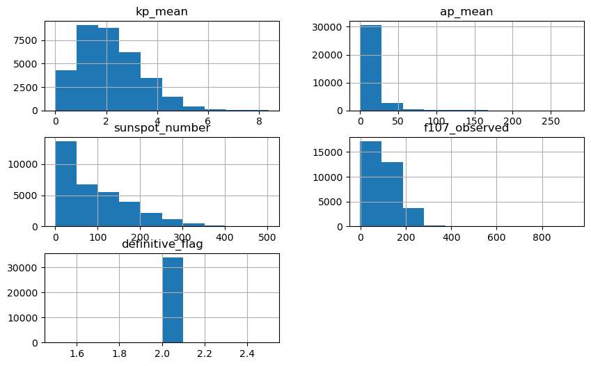

```python
df_ml.describe()
df_ml.hist(figsize=(10, 6))
```

```
array([<Axes: xlabel='date'>, <Axes: xlabel='date'>,
       <Axes: xlabel='date'>], dtype=object)
```

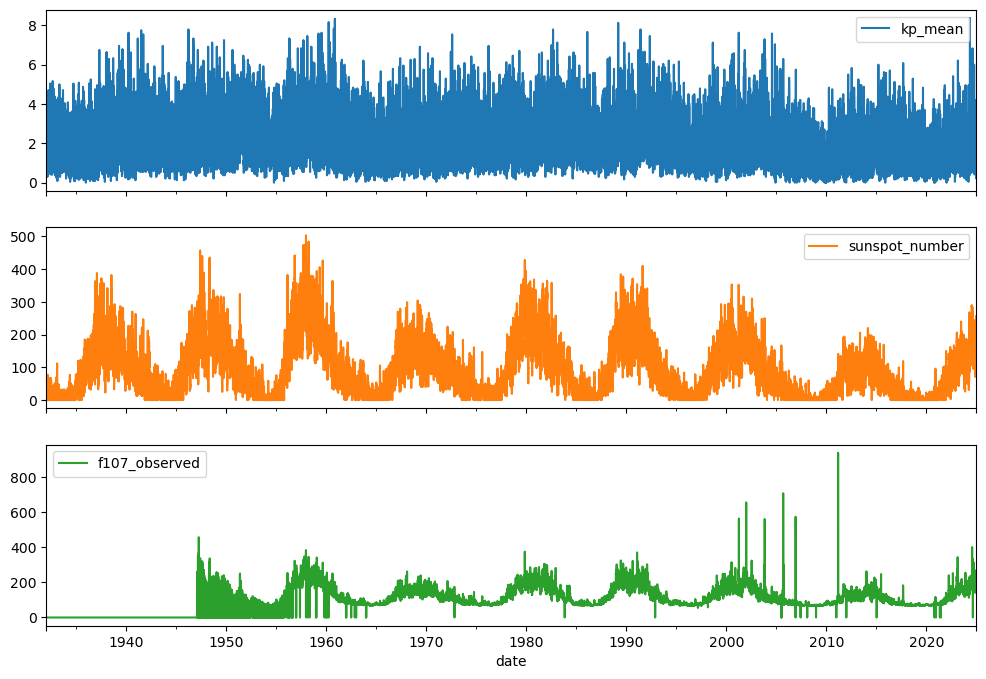

```python
df_ml[['kp_mean', 'sunspot_number', 'f107_observed']].plot(subplots=True, figsize=(12, 8))
```

f107_observed looks weird up until 1960 so I'm going to get rid of all rows before that date.

```python
df_ml = df_ml[df_ml.index >= '1960-01-01']
```

```
array([<Axes: xlabel='date'>, <Axes: xlabel='date'>,
       <Axes: xlabel='date'>], dtype=object)
```

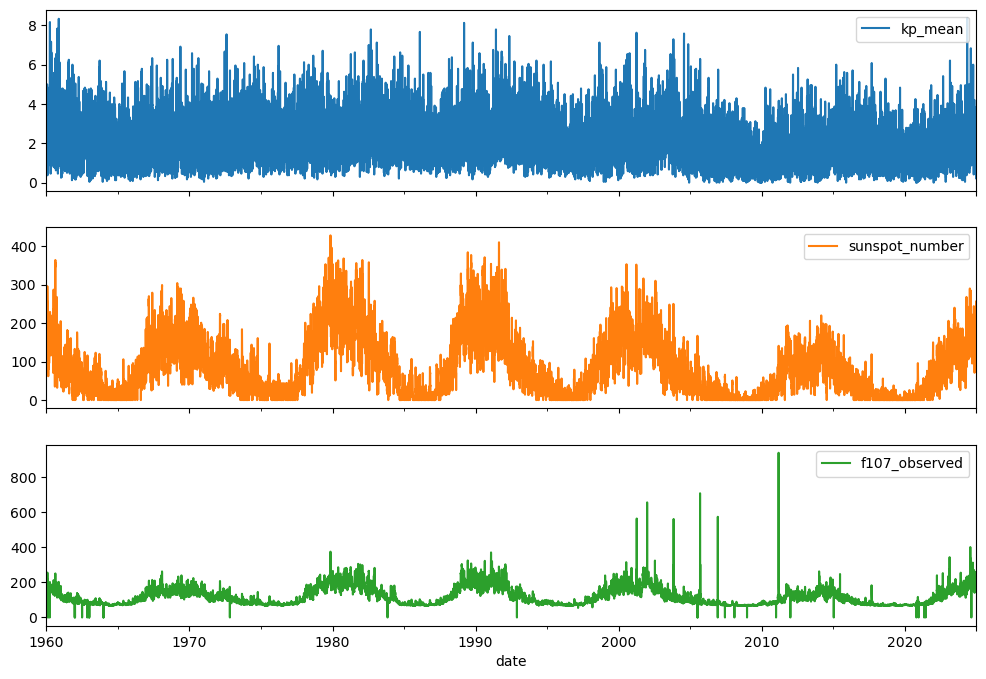

```python
df_ml[['kp_mean', 'sunspot_number', 'f107_observed']].plot(subplots=True, figsize=(12, 8))
```

## Remove outliers from f10_7 observed

```python
upper_threshold = df_ml['f107_observed'].quantile(0.99)
lower_threshold = df_ml['f107_observed'].quantile(0.01)

df_ml = df_ml[
    (df_ml['f107_observed'] > lower_threshold) &
    (df_ml['f107_observed'] < upper_threshold)
]
```

```
array([<Axes: xlabel='date'>, <Axes: xlabel='date'>,
       <Axes: xlabel='date'>], dtype=object)
```

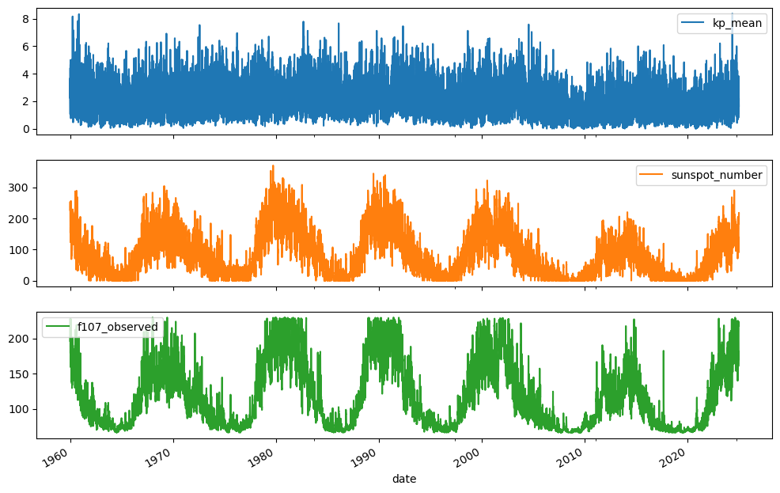

```python
df_ml[['kp_mean', 'sunspot_number', 'f107_observed']].plot(subplots=True, figsize=(12, 8))
```

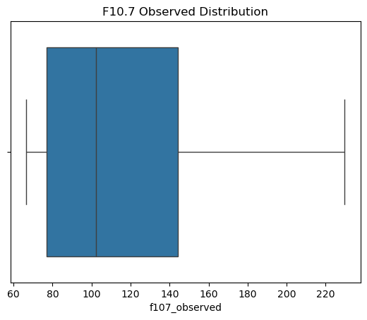

```python
import seaborn as sns
sns.boxplot(x=df_ml['f107_observed'])
plt.title("F10.7 Observed Distribution")
plt.show()
```

## Check Correlations

[figure not shown]

```python
import seaborn as sns
import matplotlib.pyplot as plt

sns.heatmap(df_ml.corr(), annot=True, cmap='coolwarm')
plt.title("Correlation Matrix")
plt.show()
```